# Project 1 - Predicting the downloads of mobile app ads. Data Science Academy

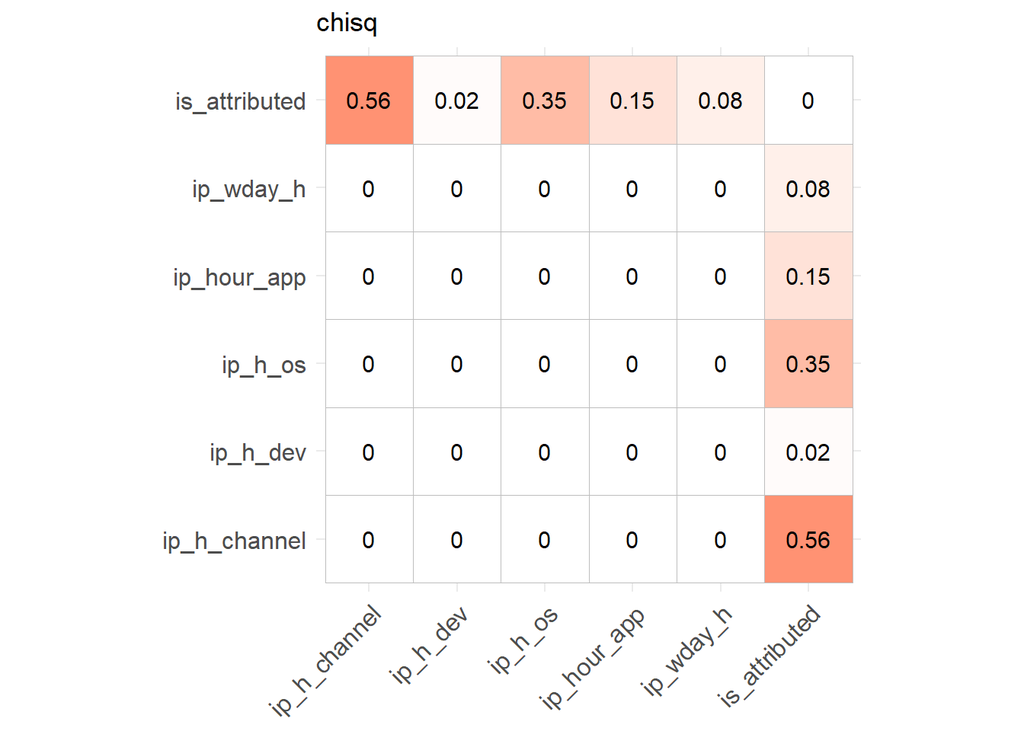

```
## [1] "Goodman's and Kruskal's tau"
```

[output not shown]

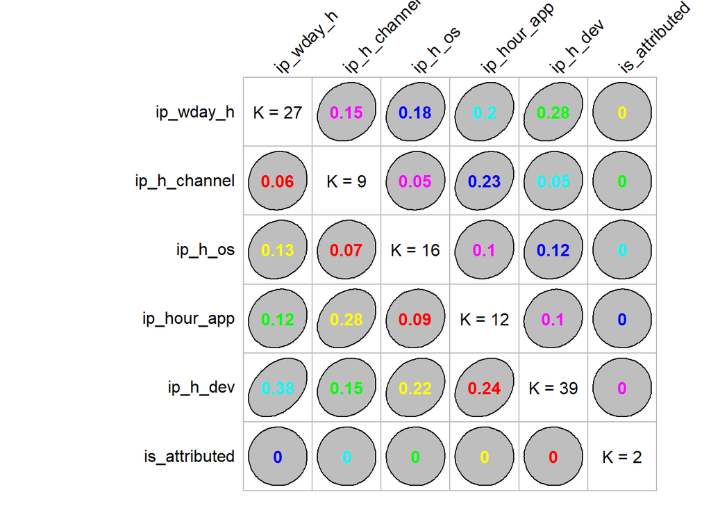

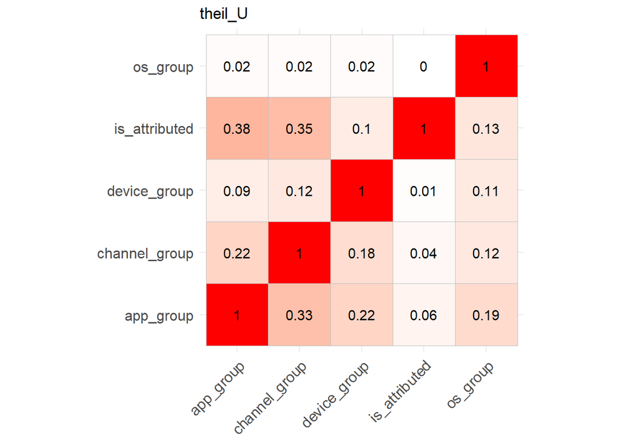

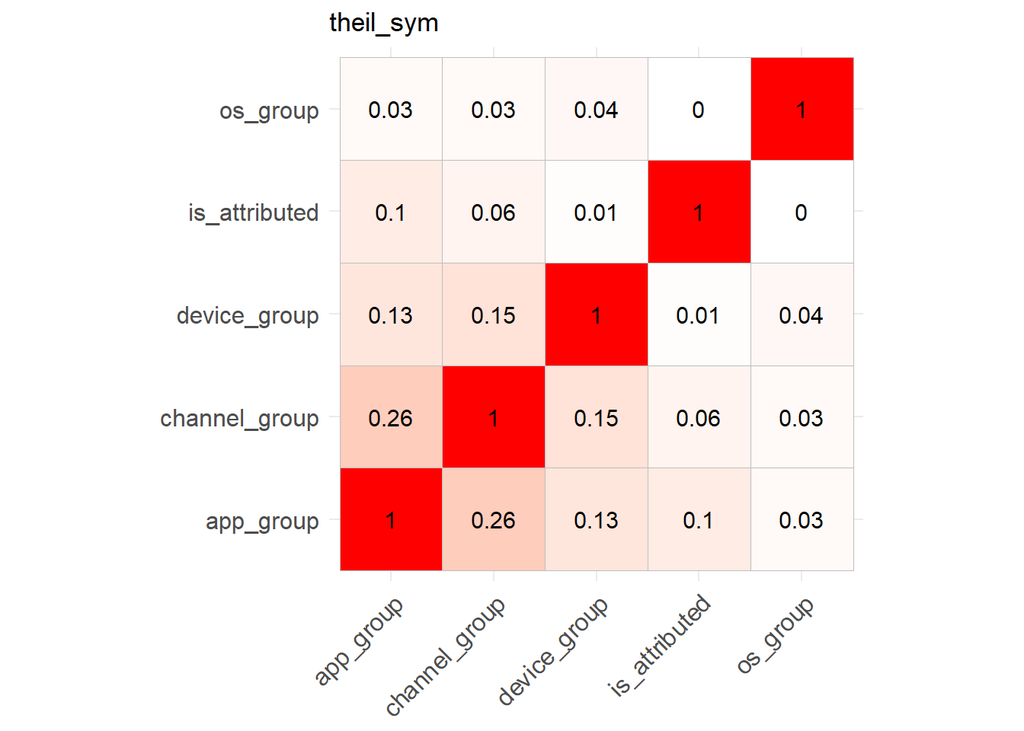

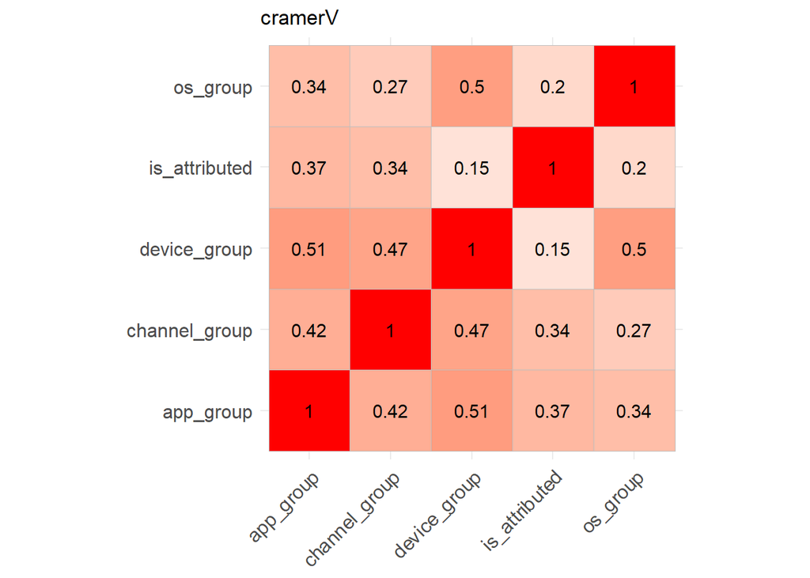

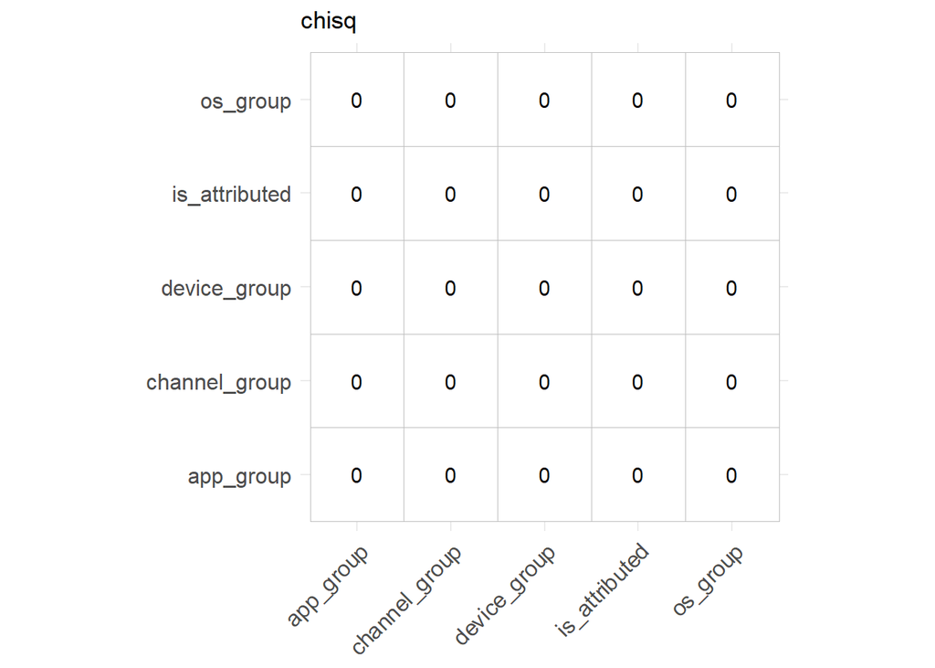

```
## [1] "Goodman's and Kruskal's tau"
```

[output not shown]

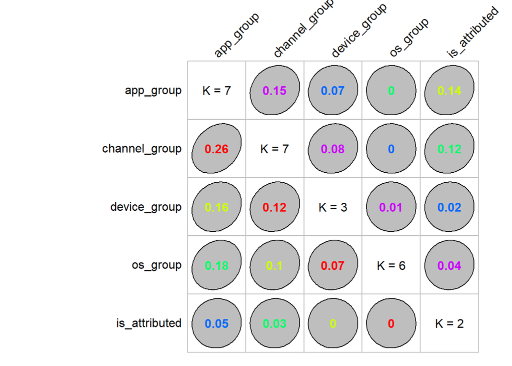

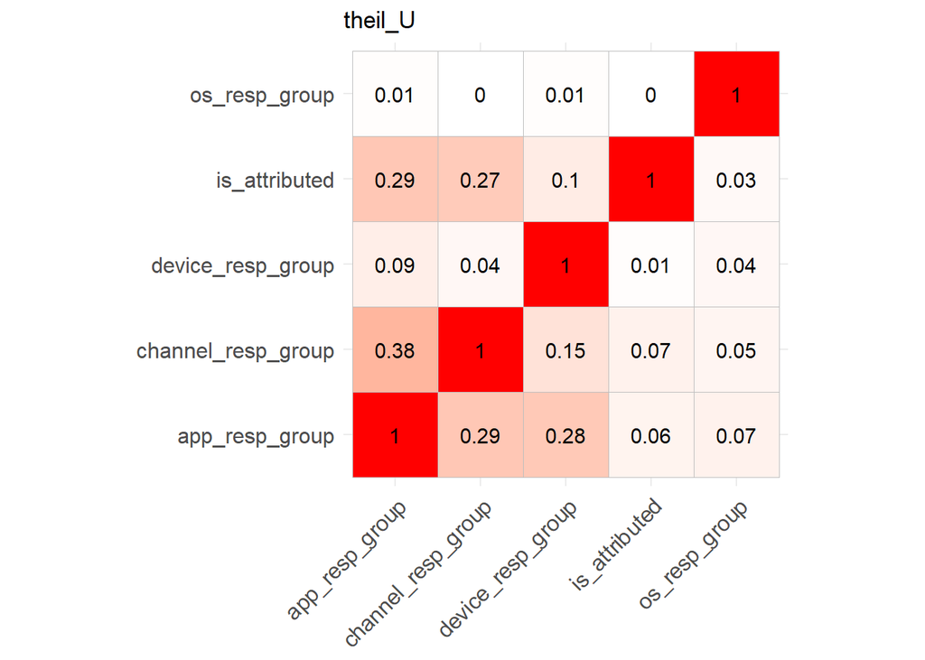

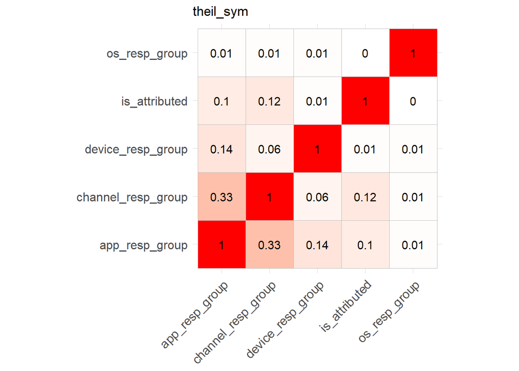

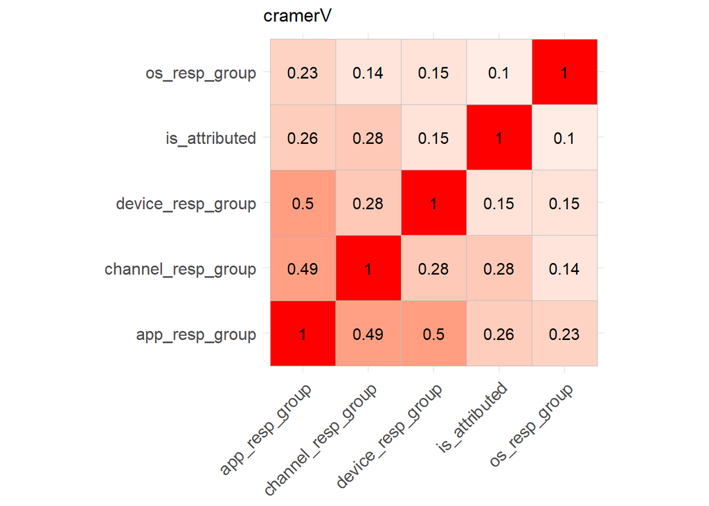

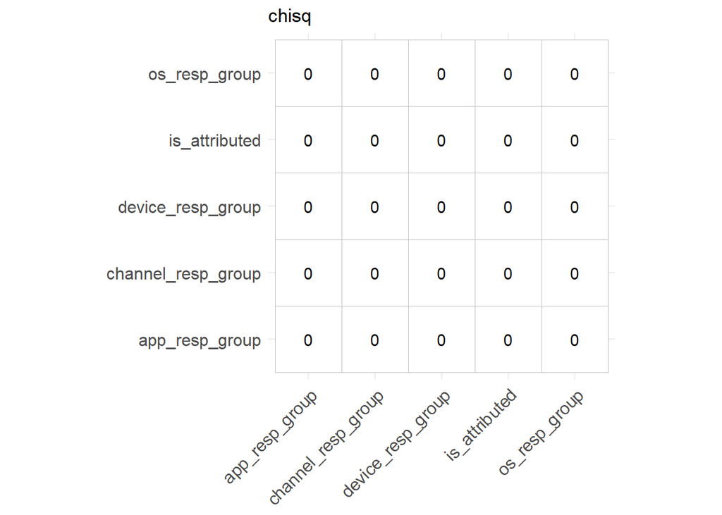

```
## [1] "Goodman's and Kruskal's tau"
```

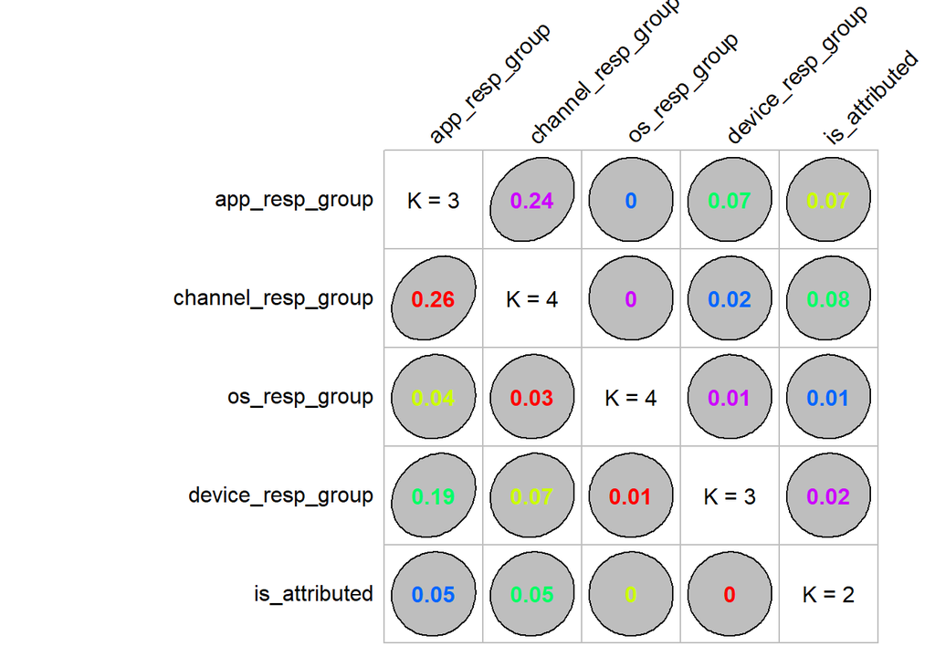

The results of Theil’s U (see theil_U and theil_sym visualization) and Goodman’s and Kruscak’s tau showed the asymmetry of the data: is_attributed is somehow predicted if the value of some features is known, but much less information can be retrived if is_attributed is known. The association x -> y is stronger with variables app and channel, and weaker with device and os.

Cramer’s V coefficient gives no information about asymmetry of association, however, the predicted association strengh given by Cramer’s V for features -> is_attributed was somewhat comparable with those of Theil’s U. On the other hand, Goodman’s and Kruskal’s tau coefficient demonstrated, in general, weaker associations.

In summary, features app, channel, os, device, both originals and the grouped ones were associated with is_attributed. Grouping those features resulted in weaker associations, which can be related with the loss of information in the grouped variables.

# Evaluating the dependence between cont_time and is_attributed

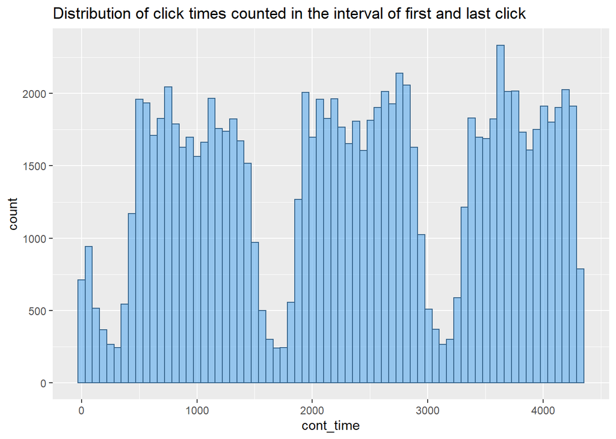

```r
train_cat %>%
  ggplot(aes(x = cont_time)) +
  geom_histogram(bins = 70, color='steelblue4', fill = 'steelblue2', alpha=0.6, position = 'identity') +
  ggtitle('Distribution of click times counted in the interval of first and last click')
```

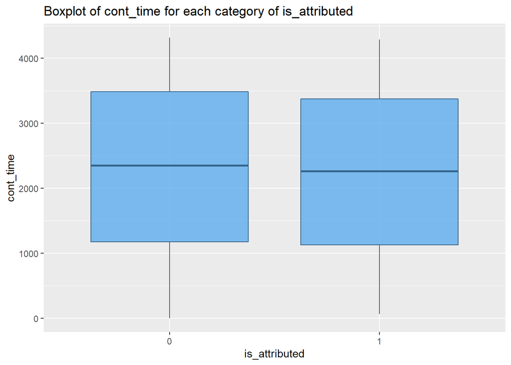

```r
train_cat %>%
ggplot(aes(x = is_attributed, y = cont_time, fill = is_attributed)) +
  geom_boxplot(color= 'steelblue4', fill='steelblue2', alpha=0.8) +
  ggtitle('Boxplot of cont_time for each category of is_attributed')
```

## Splitting the data

```r
train_model <- train_cat %>% select(-c(date))

set.seed(1045)
sample <- sample.split(train_model$is_attributed, SplitRatio = 0.70)

train_set <- subset(train_model, sample == TRUE)
test <- subset(train_model, sample == FALSE)

dim(train_set)
```

```
## [1] 70000    25
```

```r
dim(test)
```

```
## [1] 30000    25
```

## Feature Selection

Feature selection is important for two reasons: first, we have to keep the model as simple as possible; second, using insignificant variables can impact the model performance.

Methods: 1. filter methods: correlation/association, hypothesis test, information gain 2. wrapper methods: forward selection (variables are being added one by one), backward selection (variables are droped one by one), stepwise selection (both forward and backward, i.e., at each iteration a variable can be added or droped from the model) 3. embedded method

The association between variables was already tested, now I’m going to apply Random Forest to select the most important variables. In this case, the original variables were not used because they have more than 53 categorical variables. I performed different tests to evaluate the importance of variables obtained using group_categories function and another using group_target_prop function.

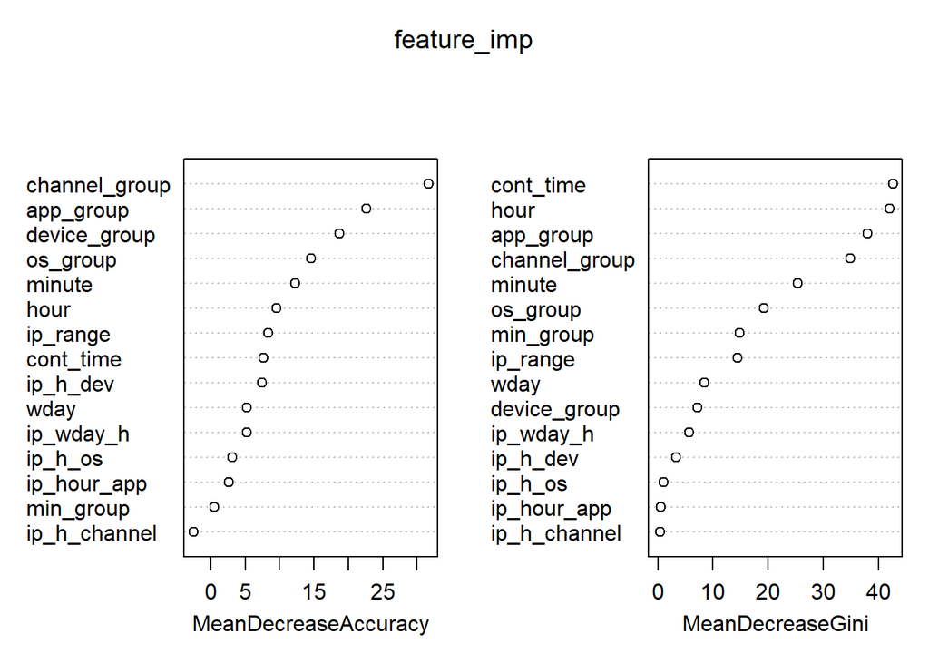

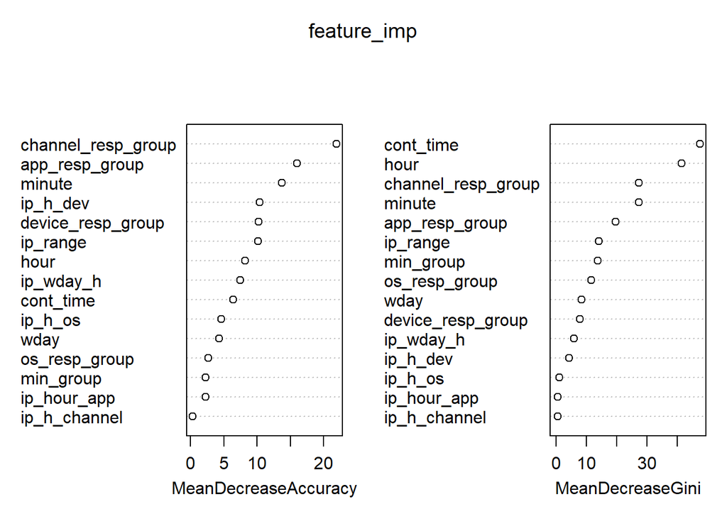

```r
names1 <- names(train_set)[-c(1:6,22:25)]
names2 <- names(train_set)[-c(1:6,18:21)]
var = list(names1, names2)

for(names in var){
  set.seed(1045)
  feature_imp <- randomForest(x=train_set[, ..names], y=train_set$is_attributed,
                              importance = TRUE)
  varImpPlot(feature_imp)
}
```

## Training C5.0 model

Using the 8 most important variables according to mean decrease accuracy.

```r
var = names(train_set)[c(18:21,9,8,10,12)]

set.seed(1045)
C50_rf_mda <- C5.0(x = train_set[,..var] , y = train_set$is_attributed, trials = 10)

evaluate_model(model = C50_rf_mda, test_set = test, variables = var, target_name = 'is_attributed')
```

```
## Confusion Matrix and Statistics
##
##           Reference
## Prediction     0     1
##          0 29802    25
##          1   130    43
##
##                Accuracy : 0.9948
##                  95% CI : (0.994, 0.9956)
##     No Information Rate : 0.9977
##     P-Value [Acc > NIR] : 1
##
##                   Kappa : 0.3547
##
##  Mcnemar's Test P-Value : <2e-16
##
##               Precision : 0.248555
##                  Recall : 0.632353
##                      F1 : 0.356846
##              Prevalence : 0.002267
##          Detection Rate : 0.001433
##    Detection Prevalence : 0.005767
##       Balanced Accuracy : 0.814005
##
##        'Positive' Class : 1
##
```

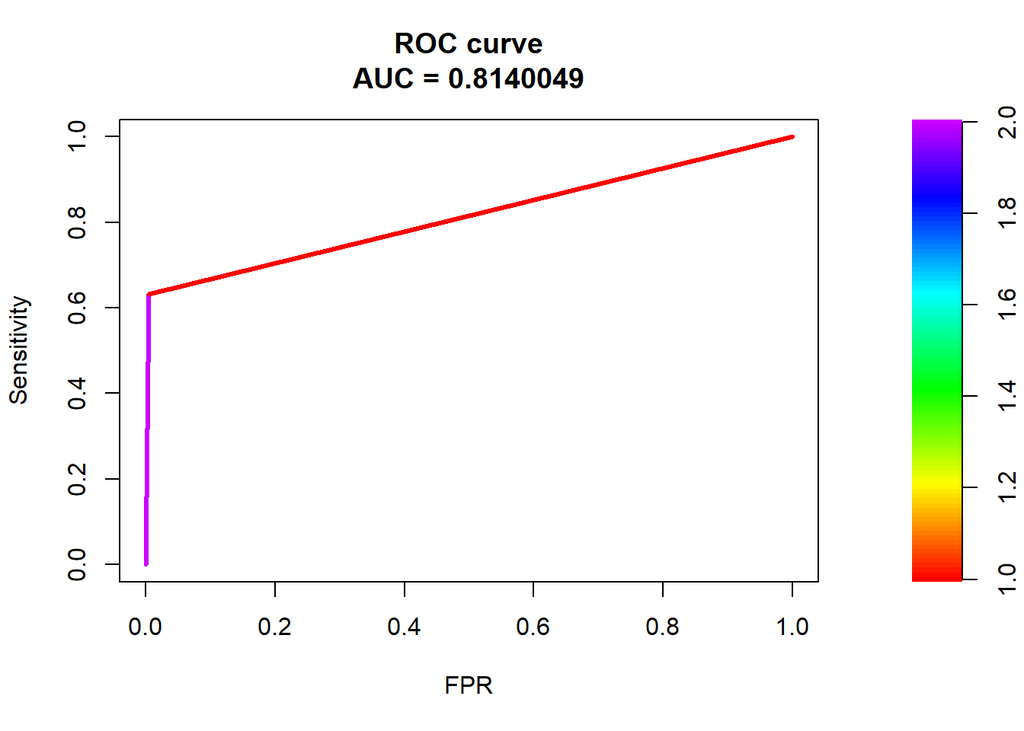

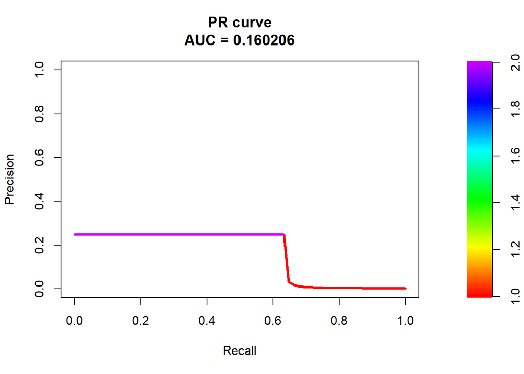

Let’s see if the model is improve by balancing the dataset using ROSE method.

```r
balanced <- ROSE(is_attributed ~.,data = train_set[,c(6,18:21,9,8,10,12)])$data

set.seed(1045)
C50_rf_mda_balanced <- C5.0(x = balanced[,var] , y = balanced$is_attributed, trials = 10)

evaluate_model(model = C50_rf_mda_balanced, test_set = test, variables = var, target_name = 'is_attributed')
```

```
## Confusion Matrix and Statistics
##
##           Reference
## Prediction     0     1
##          0 29180    28
##          1   752    40
##
##                Accuracy : 0.974
##                  95% CI : (0.9721, 0.9758)
##     No Information Rate : 0.9977
##     P-Value [Acc > NIR] : 1
##
##                   Kappa : 0.0892
##
##  Mcnemar's Test P-Value : <2e-16
##
##               Precision : 0.050505
##                  Recall : 0.588235
##                      F1 : 0.093023
##              Prevalence : 0.002267
##          Detection Rate : 0.001333
##    Detection Prevalence : 0.026400
##       Balanced Accuracy : 0.781556
##
##        'Positive' Class : 1
##
```

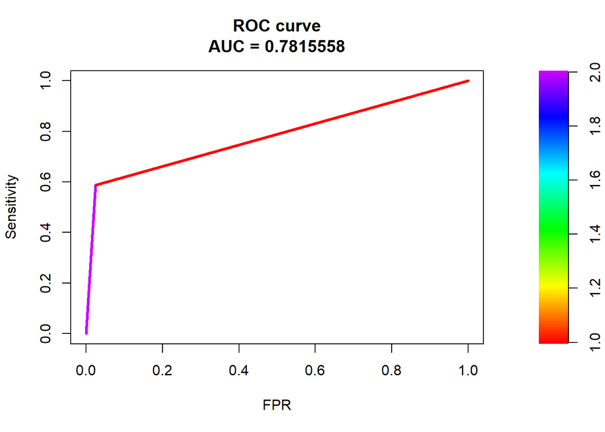

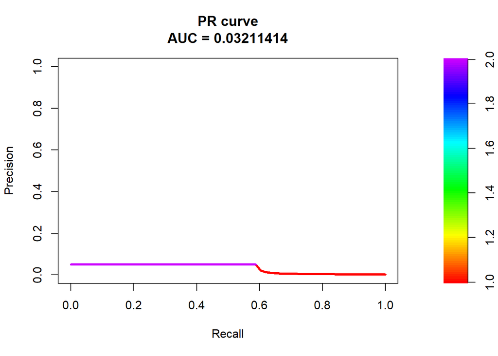

Balancing the data with Rose did not improve the model and increased significantly false positives.

```r
var = names(train_set)[c(8,18,19,20,11,10)]

set.seed(1045)
C50_rf_gini <- C5.0(x = train_set[,..var] , y = train_set$is_attributed, trials = 10)

evaluate_model(model = C50_rf_gini, test_set = test, variables = var, target_name = 'is_attributed')
```

```
## Confusion Matrix and Statistics
##
##           Reference
## Prediction     0     1
##          0 29802    25
##          1   130    43
##
##                Accuracy : 0.9948
##                  95% CI : (0.994, 0.9956)
##     No Information Rate : 0.9977
##     P-Value [Acc > NIR] : 1
##
##                   Kappa : 0.3547
##
##  Mcnemar's Test P-Value : <2e-16
##
##               Precision : 0.248555
##                  Recall : 0.632353
##                      F1 : 0.356846
##              Prevalence : 0.002267
##          Detection Rate : 0.001433
##    Detection Prevalence : 0.005767
##       Balanced Accuracy : 0.814005
##
##        'Positive' Class : 1
##
```

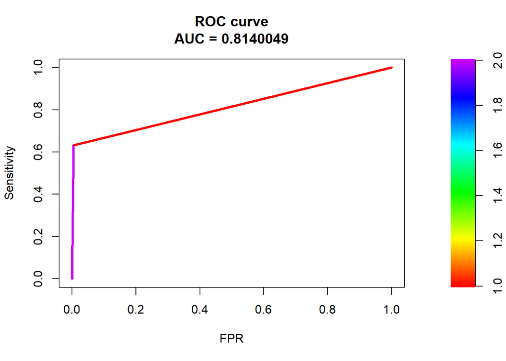

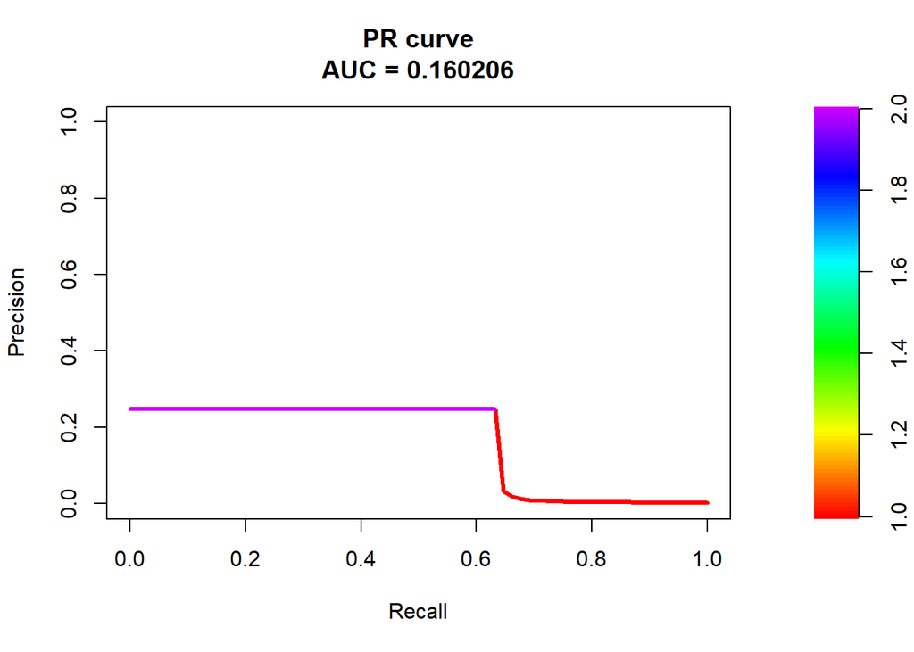

The model is comparable to that obtained with the mean decrease accuracy variables. Let’s balance the dataset.

```r
balanced <- ROSE(is_attributed ~.,data = train_set[,c(6,12,8,18,19,9,20,11,10)])$data

set.seed(1045)
C50_rf_gini_balanced <- C5.0(x = balanced[,-c(1)] , y = balanced$is_attributed, trials = 10)

evaluate_model(model = C50_rf_gini_balanced, test_set = test, variables = names(balanced), target_name = 'is_attributed')
```

```
## Confusion Matrix and Statistics
##
##           Reference
## Prediction     0     1
##          0 29459    26
##          1   473    42
##
##                Accuracy : 0.9834
##                  95% CI : (0.9819, 0.9848)
##     No Information Rate : 0.9977
##     P-Value [Acc > NIR] : 1
##
##                   Kappa : 0.1406
##
##  Mcnemar's Test P-Value : <2e-16
##
##               Precision : 0.081553
##                  Recall : 0.617647
##                      F1 : 0.144082
##              Prevalence : 0.002267
##          Detection Rate : 0.001400
##    Detection Prevalence : 0.017167
##       Balanced Accuracy : 0.800922
##
##        'Positive' Class : 1
##
```

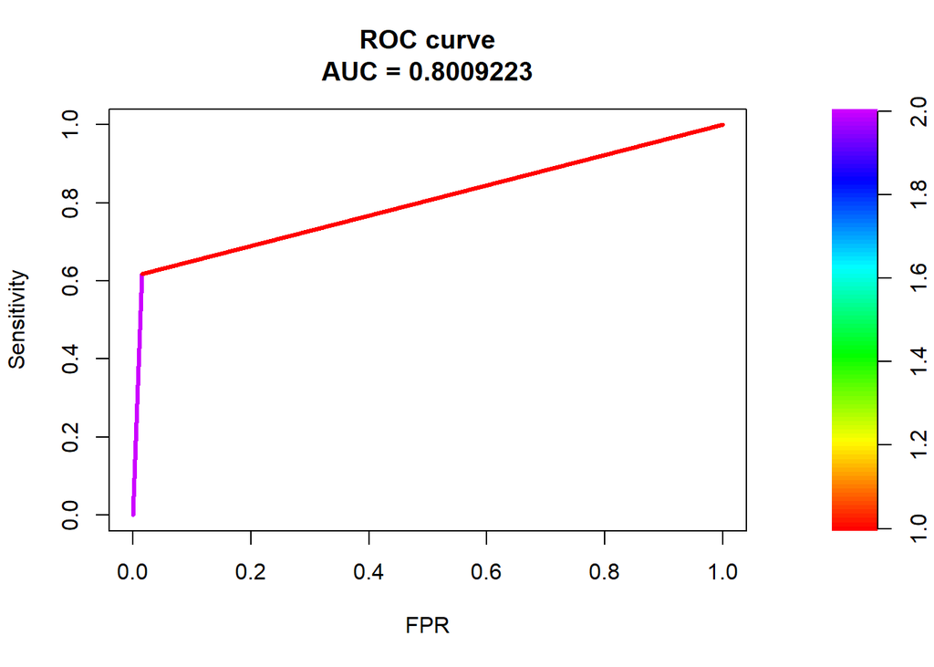

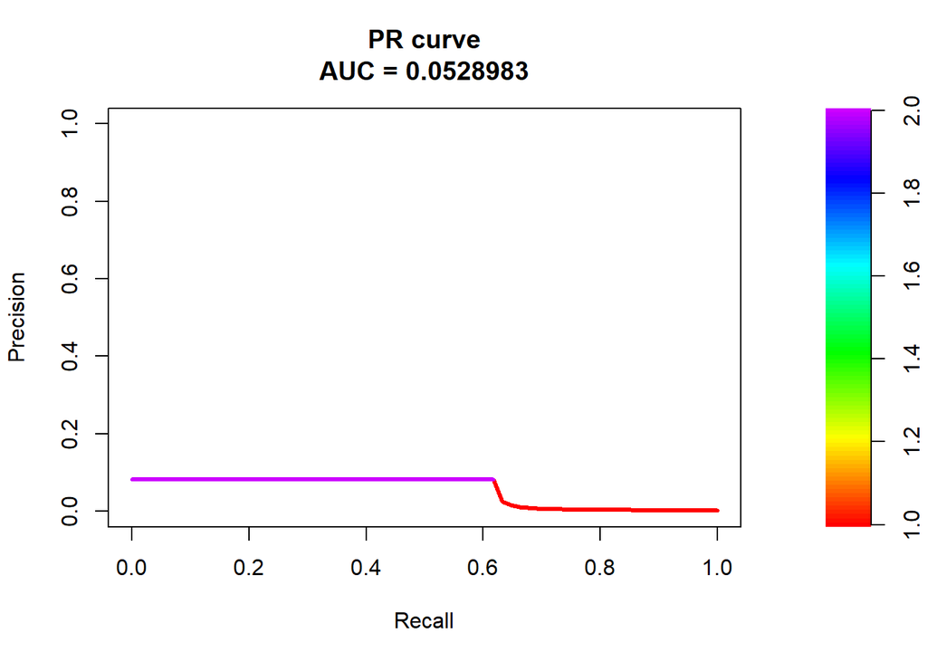

The performance of this model was worse. Thus, the mean deacrease accuracy variables will be used in further models.

PS: Variables with resp_group sufixe will not be tested because they presented lower importance than those with group sufixe.

# Evaluating xgboost balacing the data with ROSE

```r
var = names(train_set)[c(18:21,9,10,6)]
balanced <- ROSE(is_attributed ~.,data = train_set[,c(6,18:21,9,8,10,12)])$data

prediction1 <- train_xgboost(target = 'is_attributed', variables = var,
                            train_dataset = balanced, test_dataset = test)
evaluate_model(NULL, test, 'is_attributed', predictions = prediction1$predictions)
```

```
## Confusion Matrix and Statistics
##
##           Reference
## Prediction     0     1
##          0 28128    16
##          1  1804    52
##
##                Accuracy : 0.9393
##                  95% CI : (0.9366, 0.942)
##     No Information Rate : 0.9977
##     P-Value [Acc > NIR] : 1
##
##                   Kappa : 0.0499
##
##  Mcnemar's Test P-Value : <2e-16
##
##               Precision : 0.028017
##                  Recall : 0.764706
##                      F1 : 0.054054
##              Prevalence : 0.002267
##          Detection Rate : 0.001733
##    Detection Prevalence : 0.061867
##       Balanced Accuracy : 0.852218
##
##        'Positive' Class : 1
##
```

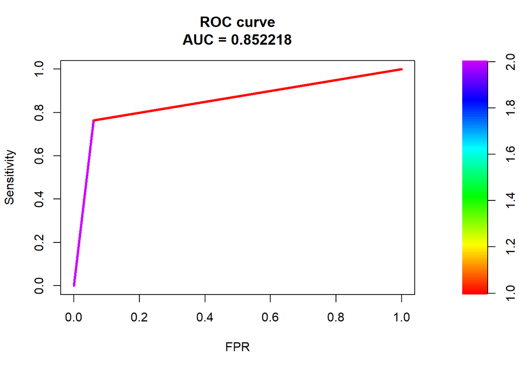

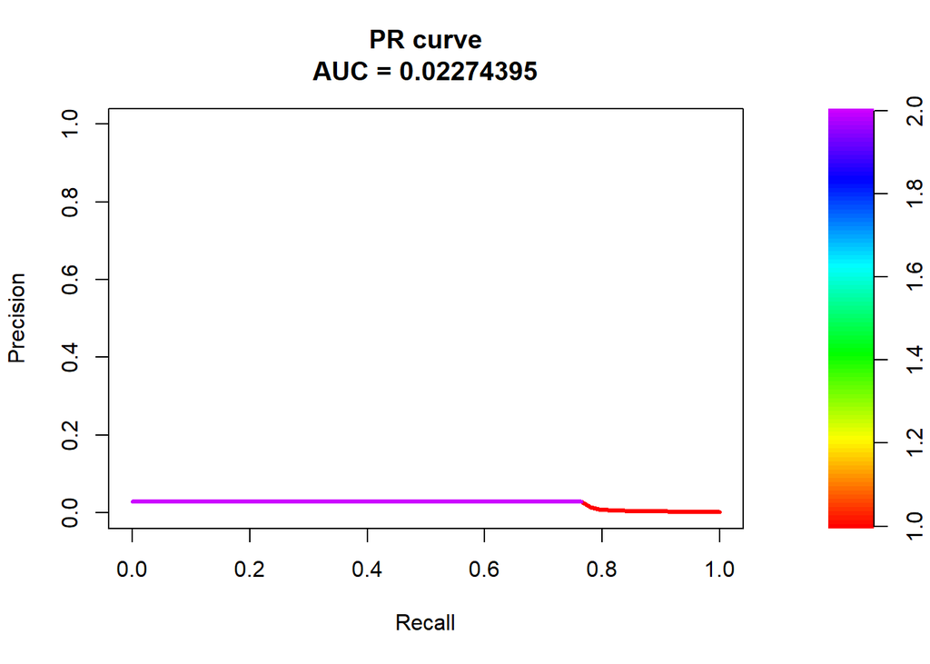

This model presented better performance to predict the true positive responses, but false positive increased significantly.

## Using SMOTE to balance the class

As an attempt to improve recall and precision, I’m going to use SMOTE method to balance the classes. Different oversampling fractions of the minority class will be used and the performance of respective models evaluated. Three different learning models will be used: C5.0, xgboost and SMV.

```r
sampling = c(100,300,700,1000,1500,2000,2500)
```

```r
names = names(train_set)[c(18:21,9,8,10,12,6)]
learner = c(1:3)
for(i in learner){
  grid_search_smote(train_data = train_set, test_data = test, target = 'is_attributed',
                    features = names, oversamples = sampling, model = i)
}
```

```
## [1] "100 C50"
## Area under the curve (AUC): 0.932
##
## pred     0     1
##    0 29354     8
##    1   578    60
## [1] "300 C50"
## Area under the curve (AUC): 0.919
##
## pred     0     1
##    0 29507    10
##    1   425    58
## [1] "700 C50"
## Area under the curve (AUC): 0.927
##
## pred     0     1
##    0 29520     9
##    1   412    59
## [1] "1000 C50"
## Area under the curve (AUC): 0.919
##
## pred     0     1
##    0 29514    10
##    1   418    58
## [1] "1500 C50"
## Area under the curve (AUC): 0.928
##
## pred     0     1
##    0 29591     9
##    1   341    59
## [1] "2000 C50"
## Area under the curve (AUC): 0.907
##
## pred     0     1
##    0 29649    12
##    1   283    56
## [1] "2500 C50"
## Area under the curve (AUC): 0.913
##
## pred     0     1
```

[output cut: 71 more lines]

```
## pred     0     1
##    0 29483    10
##    1   449    58
## [1] "2000 SVM"
## Area under the curve (AUC): 0.926
##
## pred     0     1
##    0 29457     9
##    1   475    59
## [1] "2500 SVM"
## Area under the curve (AUC): 0.926
##
## pred     0     1
##    0 29468     9
##    1   464    59
```

## Final model

The best model was C5.0 with smote technique to balance the classes using perc.over = 1500. This model was chose because it presented the best trade-off between false positives and true positives.

```r
var = names(train_set)[c(18:21,9,8,10,12,6)]
set.seed(1045)
smoted_data <- SMOTE(is_attributed ~., data = train_set[,..var], perc.over = 1500, k = 5,
                     perc.under = 400)
set.seed(1045)
var1 <- var[var != 'is_attributed']
model_final <- C5.0(x = smoted_data[,..var1] , y = smoted_data$is_attributed, trials = 10)
evaluate_model(model = model_final, test_set = test, variables = var1, target_name = 'is_attributed')
```

```
## Confusion Matrix and Statistics
##
##           Reference
## Prediction     0     1
##          0 29591     9
##          1   341    59
##
##                Accuracy : 0.9883
##                  95% CI : (0.9871, 0.9895)
##     No Information Rate : 0.9977
##     P-Value [Acc > NIR] : 1
##
##                   Kappa : 0.2492
##
##  Mcnemar's Test P-Value : <2e-16
##
##               Precision : 0.147500
##                  Recall : 0.867647
##                      F1 : 0.252137
##              Prevalence : 0.002267
##          Detection Rate : 0.001967
##    Detection Prevalence : 0.013333
##       Balanced Accuracy : 0.928127
##
##        'Positive' Class : 1
##
```

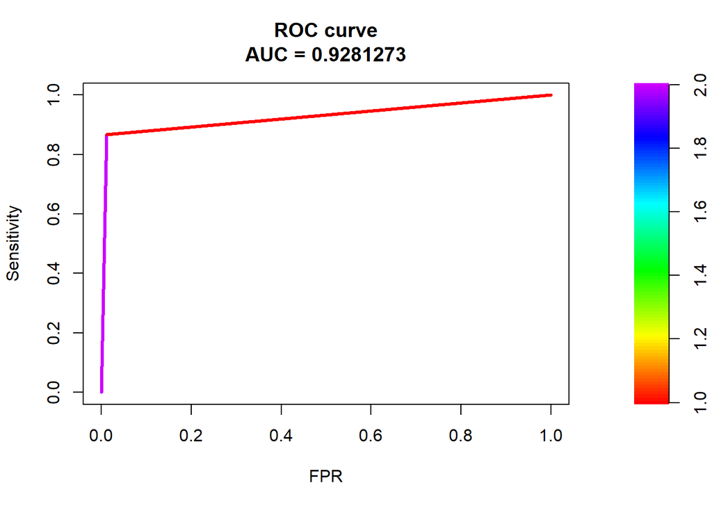

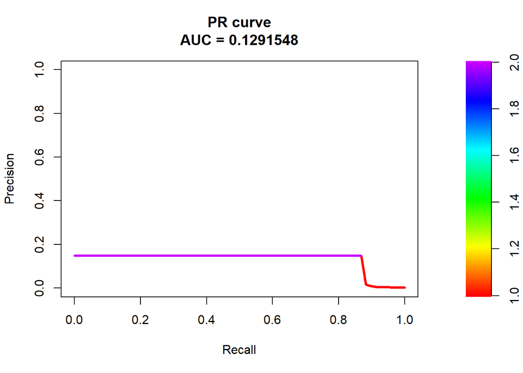

## References

https://www.coursera.org/lecture/inferential-statistics/2-03-interpreting-the-chi-squared-test-82xpS

http://stats.lse.ac.uk/bergsma/pdf/cramerV3.pdf)

http://jamesmarquezportfolio.com/correlation_matrices_in_r.html#.WP6WeFB-BPd.facebook

https://www.datacamp.com/community/blog/r-correlation-tutorial

http://www.sthda.com/english/wiki/visualize-correlation-matrix-using-correlogram

http://www.sthda.com/english/wiki/correlation-analyses-in-r

https://rstudio-pubs-static.s3.amazonaws.com/558925_38b86f0530c9480fad4d029a4e4aea68.html#thiels-u-correl ation-coefficient-uncertainty-coefficient

http://www.sthda.com/english/wiki/chi-square-test-of-independence-in-r

http://www.sthda.com/english/wiki/correlation-test-between-two-variables-in-r#at_pco=smlwn-1.0&at_si=5f2d6398d89d6897&at_ab=per-2&at_pos=0&at_tot=1

https://machinelearningmastery.com/tour-of-evaluation-metrics-for-imbalanced-classification/

https://machinelearningmastery.com/cost-sensitive-svm-for-imbalanced-classification/